# Activity: Street or Road?

Sijie Wu

## Load in the data

```r
#load libraries
library(dplyr)
library(readr)
library(tidyr)
library(ggplot2)

#load in the data here
# we will only be using the "street-addresses.csv" file from the text
addresses <- read_csv("https://mdbeckman.github.io/dcSupplement/data/street-addresses.csv")
head(addresses)
```

| address |
| --- |
| 2117 MARINER CIRCLE |
| 101 EPPING WAY |
| PO BOX 58592 |
| 5102 ECHO RIDGE RD |
| PO BOX 37218 |
| PO BOX 37218 |

```r
NA
```

## Recreate Solved Example using `sample(50)`

```r
# Sample 50 addresses
sample_addresses <- addresses %>% sample_n(size = 50)

# Define pattern to identify PO Box addresses
po_pattern <- "BOX\\s+(\\d+)"

# Find matches for PO Box addresses
po_matches <- sample_addresses %>% filter(grepl(po_pattern, address))

# Find addresses that don't match PO Box pattern
po_dont <- sample_addresses %>% filter(!grepl(po_pattern, address))

# Extract PO Box numbers
box_numbers <- po_matches %>%
  tidyr::extract(address, into = "boxnum", regex = po_pattern)
```

## Recreate Soved Example using the entire `Address` data set

```r
# Find matches for PO Box addresses in the entire dataset
po_matches_full <- addresses %>% filter(grepl(po_pattern, address))

# Extract PO Box numbers from the entire dataset
box_numbers_full <- po_matches_full %>%
  tidyr::extract(address, into = "boxnum", regex = po_pattern)
```

#### Additional Question: How many addresses are a PO BOX (including NCSU BOX)?

```r
# Count the number of PO Box addresses
num_po_boxes <- nrow(po_matches_full)
num_po_boxes
```

```
[1] 11100
```

There are 11100 addresses a PO BOX.

## Back to the Streets: Your Turn

#### Part 1: Explain (in english) each line of the following code chunk

```r
pattern <- "(ST|RD|ROAD)"
LeftOvers <-
  addresses %>%
  filter( !grepl(pattern, address),
          !grepl("\\sAPT|UNIT\\s[\\d]+$", address),
          !grepl(" BOX ", address)
          )
```

pattern <- “(ST|RD|ROAD)”: Defines a pattern to match street endings like “ST”, “RD”, and “ROAD”. LeftOvers <- addresses %>%: Begins a pipeline to filter the addresses dataset. filter(!grepl(pattern, address),: Filters out addresses that contain the pattern defined above. !grepl(“\sAPT|UNIT\s[\d]+$”, address),: Further filters out addresses that contain apartment or unit numbers. !grepl(” BOX “, address)): Additionally filters out addresses containing the word”BOX”.

#### Part 2: Implement your method on the entire `Addresses` data set. Explain how your code works line by line.

```r
# Define a more comprehensive pattern to include additional street types
street_pattern <- "(ST|RD|ROAD|LANE|AVE|BLVD|DR|COURT|CIRCLE|HWY|WAY|TRL)"

# Find matches for street types
street_matches <- addresses %>% filter(grepl(street_pattern, address))

# Extract the street types
street_types <- street_matches %>%
  tidyr::extract(address, into = "street_type", regex = street_pattern)
```

- street_pattern <- “(ST|RD|ROAD|LANE|AVE|BLVD|DR|COURT|CIRCLE|HWY|WAY|TRL)”: Defines a pattern to match various common street types such as “ST”, “RD”, “ROAD”, “LANE”, “AVE”, “BLVD”, “DR”, “COURT”, “CIRCLE”, “HWY”, “WAY”, and “TRL”.
- street_matches <- addresses %>%: Begins a pipeline to filter the addresses dataset.
- filter(grepl(street_pattern, address)): Filters the dataset to retain only the rows where the address column contains one of the street types defined in street_pattern.
- street_types <- street_matches %>%: Continues the pipeline with the filtered dataset street_matches.
- tidyr::extract(address, into = “street_type”, regex = street_pattern): Extracts the specific street type from each address and places it into a new column called street_type using the regular expression defined in street_pattern.

#### Additional Question 1: Present your result from part 2 by providing a table in descending order of popularity for the street name endings you found

```r
# Count the occurrences of each street type
street_type_counts <- street_types %>%
  count(street_type, sort = TRUE)

# Display the counts
street_type_counts
```

| street_type | n |
| --- | --- |
| ST | 915 |
| DR | 783 |
| RD | 757 |
| AVE | 272 |
| ROAD | 188 |
| WAY | 141 |
| LANE | 130 |
| COURT | 79 |
| CIRCLE | 58 |
| BLVD | 43 |

[output cut: 2 more lines]

```r
NA
```

#### Additional Question 2: Present your result by using ggplot to a bar chart in descending order of popularity for the street name endings you found previously.

Note: make sure your order street names according to popularity, not alphabetically.

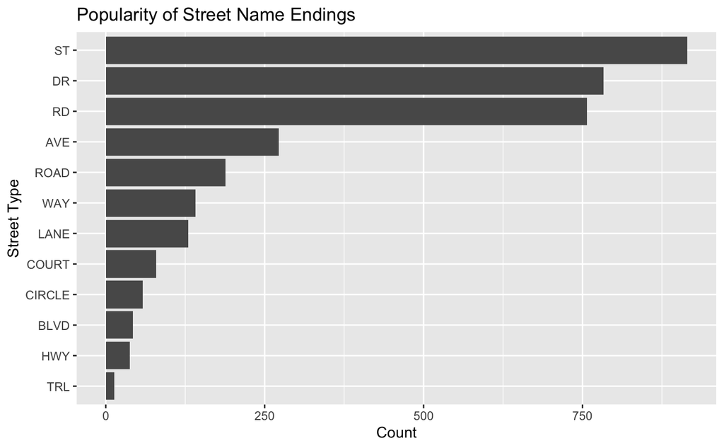

```r
# Plot the street name endings using ggplot
ggplot(street_type_counts, aes(x = reorder(street_type, n), y = n)) +
  geom_bar(stat = "identity") +
  coord_flip() +
  labs(title = "Popularity of Street Name Endings",
       x = "Street Type",
       y = "Count")
```